# Generalized linear mixed models (GLMM)

Nick Green, Kennesaw State University

December 22, 2021

# 1 Overview

Just as the linear mixed model (LMM) is an extension of the linear model, the **generalized linear mixed model (GLMM)** is an extension of the generalized linear model (GLM). The difference between the LMM and GLMM is the same as the difference between the LM and GLM: the response values can come from distributions other than the normal, and the model can be linear on a different scale than of the original scale (i.e., the link scale).

# 2 Definition

The equations for a simple GLMM, with normal (Gaussian) family and identify link function, one continuous predictor variable *X*, and random intercepts and slope by a factor *Z*, are shown below. The normal distributions of the random effects are presented as parameterized by a mean $\mu$ and variance $\sigma^2$ (or sometimes SD $\sigma$)[^1].

| Component | Expression |
| --- | --- |
| Stochastic part (*Y* values) | $y_i \sim Normal\left(\mu_i,\sigma^2\right)$ |
| Link function | $E\left(y_i\right)=\mu_i=\eta_i$ |
| Linear predictor | $\eta_i=\beta_{0,Z}+\beta_{1,Z}X_i$ |
| Random intercepts | $\beta_{0,Z} \sim Normal\left(\mu_{\beta_0},\sigma_{\beta_0}^2\right)$ |
| Random slopes | $\beta_{1,Z} \sim Normal\left(\mu_{\beta_1},\sigma_{\beta_1}^2\right)$ |

# 3 GLMM on simulated data

The code below simulates the dataset described above. First the dataset structure is defined. Then, the **hyperparameters**, which define the distribution of random effects, are set. These are then used to define the group-level parameters and the individual observations.

```r
set.seed(123)

# years in study
n.groups <- 12
# random number of sites each year
n.sample <- sample(8:20, n.groups, replace=TRUE)

# hyperparameters
mu.beta0 <- 1.5
sd.beta0 <- 1.7
mu.beta1 <- -6.8
sd.beta1 <- 0.1

# draw random effects
beta0 <- rnorm(n.groups, mu.beta0, sd.beta0)
beta1 <- rnorm(n.groups, mu.beta1, sd.beta1)

# set up data frame with explanatory variable.
dlist <- vector("list", n.groups)
for(i in 1:n.groups){
    dlist[[i]] <- data.frame(year=i, site=1:n.sample[i])
    dlist[[i]]$urb <- runif(n.sample[i], 0, 1)
}
sim <- do.call(rbind, dlist)

# add coefficients for each observation
sim$beta0 <- beta0[sim$year]
sim$beta1 <- beta1[sim$year]

# calculate linear predictor eta (logit scale)
# and probability p (probability scale)
sim$eta <- sim$beta0+sim$beta1*sim$urb
sim$p <- plogis(sim$eta)

# apply stochastic part of model (Bernoulli draws)
sim$y <- rbinom(nrow(sim), 1, sim$p)
```

Let’s start the analysis by examining the data:

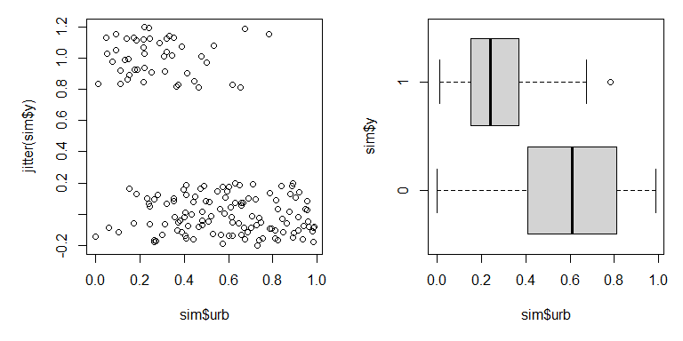

```r
par(mfrow=c(1,2), mar=c(5.1, 5.1, 1.1, 1.1))
plot(sim$urb, jitter(sim$y))
boxplot(sim$urb~sim$y, horizontal=TRUE)
```

The figure suggests that increasing urbanization tends to decrease occupancy by this bird species. This makes sense, biologically, but it also appears that there is a lot of variation in urbanization within the sites where the bird occurs and the sites where it doesn’t. Maybe there is some variation related to year?

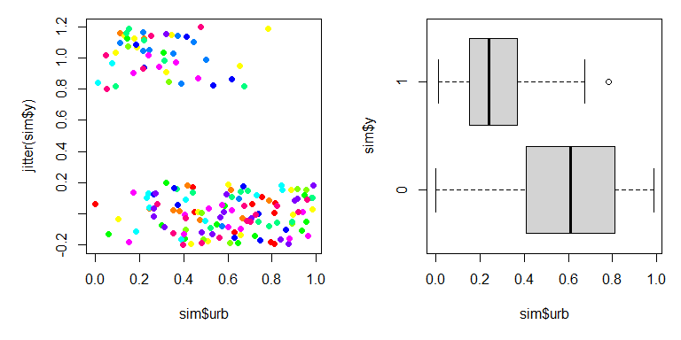

```r
# add colors for each year
cols <- rainbow(n.groups)
sim$col <- cols[sim$year]

par(mfrow=c(1,2), mar=c(5.1, 5.1, 1.1, 1.1))
plot(sim$urb, jitter(sim$y), col=sim$col, pch=16)
boxplot(sim$urb~sim$y, horizontal=TRUE)
```

With so many groups (years) it’s hard to tell if year might be affecting the relationship between occupancy and urbanization. Let’s use package `lattice` to make a hierarchical plot that shows the groups separately.

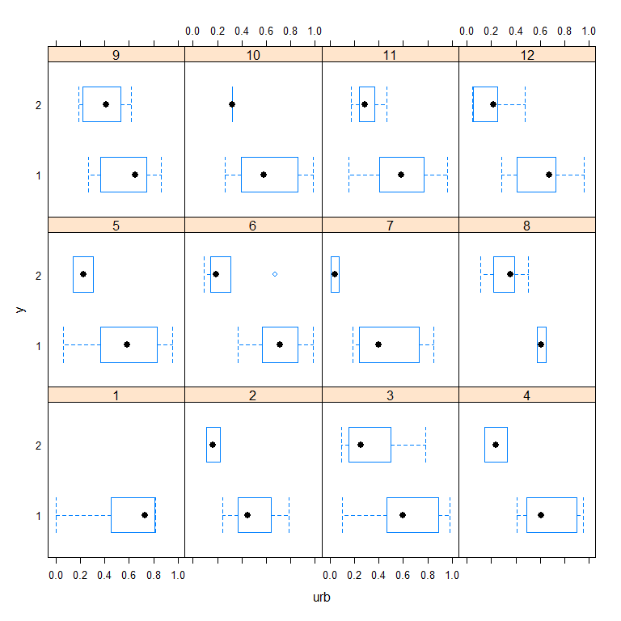

```r
library(lattice)
bwplot(y~urb|factor(year), data=sim)
```

```r
library(lme4)
mod1 <- glmer(y~urb+(1|year), data=sim, family=binomial)
mod2 <- glmer(y~urb+(0+urb|year), data=sim, family=binomial)
mod3 <- glmer(y~urb+(urb|year), data=sim, family=binomial)
mod4 <- glmer(y~urb+(urb||year), data=sim, family=binomial)
```

All of the models converged[^2], so let’s use AIC to determine which model is the best supported by the data.

```r
aic.df <- AIC(mod1, mod2, mod3, mod4)
aic.df$delta <- aic.df$AIC - min(aic.df$AIC)
aic.df$wt <- exp(-0.5*aic.df$delta)
aic.df$wt <- aic.df$wt/sum(aic.df$wt)
aic.df <- aic.df[order(-aic.df$wt),]
aic.df
```

```
##      df      AIC    delta         wt
## mod1  3 139.7622 0.000000 0.50498148
## mod2  3 141.2993 1.537081 0.23415450
## mod4  4 141.7594 1.997213 0.18603135
## mod3  5 143.5807 3.818534 0.07483267
```

Interestingly, AIC identifies model 1 (random intercept) as the best fitting model, when we know that model 4 (random uncorrelated slopes and intercepts) is the truth. Looking back at the simulation parameters, can you guess why this happened? However, $\Delta\left(AIC\right)$ was <2 for models 1, 2, and 4, suggesting that any of them could be considered “best fitting”.

Inspect the outputs to see what the parameter estimates are. The estimated intercept and slope aren’t very close to the true values (`mu.beta0` and `mu.beta1`), but this might have something do with the large variability in the intercepts (`sd.beta0`).

```r
summary(mod1)
```

```
## Generalized linear mixed model fit by maximum likelihood
##   (Laplace Approximation) [glmerMod]
##  Family: binomial  ( logit )
## Formula: y ~ urb + (1 | year)
##    Data: sim
##
##      AIC      BIC   logLik deviance df.resid
##    139.8    149.1    -66.9    133.8      161
##
## Scaled residuals:
##     Min      1Q  Median      3Q     Max
## -2.8969 -0.4530 -0.1617  0.3846  4.1386
##
## Random effects:
##  Groups Name        Variance Std.Dev.
##  year   (Intercept) 1.137    1.066
## Number of obs: 164, groups:  year, 12
##
## Fixed effects:
##             Estimate Std. Error z value Pr(>|z|)
## (Intercept)    1.959      0.602   3.254  0.00114 **
## urb           -7.312      1.330  -5.496 3.88e-08 ***
## ---
## Signif. codes:  0 '***' 0.001 '**' 0.01 '*' 0.05 '.' 0.1 ' ' 1
##
## Correlation of Fixed Effects:
##     (Intr)
## urb -0.753
```

The intercepts vary quite a bit between years:

```r
coef(mod1)$year
```

```
##    (Intercept)       urb
## 1    0.8792071 -7.312053
## 2    1.4874052 -7.312053
## 3    2.8794661 -7.312053
## 4    2.0679683 -7.312053
## 5    1.3682659 -7.312053
## 6    2.5975640 -7.312053
## 7    0.9167481 -7.312053
## 8    3.6762635 -7.312053
## 9    2.6771235 -7.312053
## 10   1.1477449 -7.312053
## 11   2.0878343 -7.312053
## 12   2.0208604 -7.312053
```

Plotting the intercept vs. year (i.e., time) might tell us something about how environmental factors varied over time.

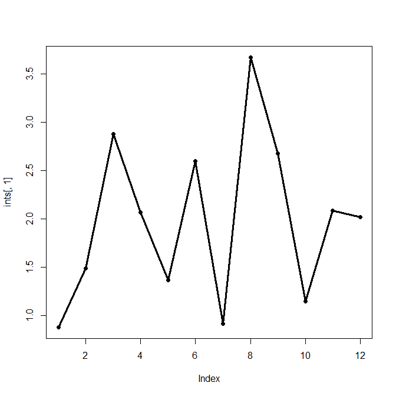

```r
ints <- coef(mod1)$year
par(mfrow=c(1,1))
plot(ints[,1], type="o", lwd=3, pch=16)
```

We’ll finish our example GLMM analysis by plotting the model predictions.

```r
# number of points and x values
pn <- 50
px <- seq(0, 1, length=pn)

# predictions by level (year)
dx1 <- expand.grid(year=1:n.groups, urb=px)
dx1 <- dx1[order(dx1$year, dx1$urb),]

# coefficients (include random beta0)
dx1$y <- predict(mod1, newdata=data.frame(dx1), type="link")
dx1$y <- plogis(dx1$y)
dx1$col <- cols[dx1$year]

# predictions for "average"
dx2 <- data.frame(year=NA, urb=px)
dx2$y <- predict(mod1, newdata=data.frame(dx2),
    type="link", re.form=NA, allow.new.levels=TRUE)
dx2$y <- plogis(dx2$y)
```

Now make the plot:

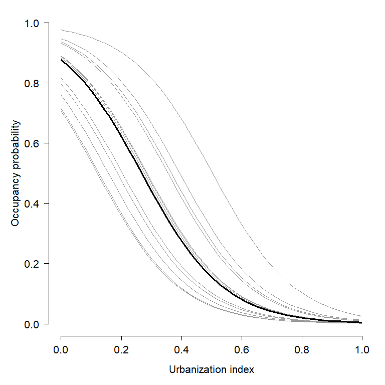

```r
par(mfrow=c(1,1), mar=c(5.1, 5.1, 1.1, 1.1),
    lend=1, las=1, bty="n",
    cex.axis=1.3, cex.lab=1.3)
plot(dx1$urb, dx1$y, type="n",
    ylim=c(0,1), ylab="Occupancy probability",
    xlab="Urbanization index")
for(i in 1:n.groups){
    flag <- which(dx1$year==i)
    points(dx1$urb[flag], dx1$y[flag], type="l", col="grey60")
}
points(dx2$urb, dx2$y, type="l", lwd=3)
```

# 4 GLMM on real data

Vicente et al. (2005) studied the distribution of the parasitic nematode *Elaphostrongylus cervi* in red deer (*Cervus elephus*) in Spain (below)[^3]. Red deer are the primary hosts of *E. cervi*, which primarily affect the hosts’ lung tissue. Vicente et al. (2005) surveyed deer feces on many farms in Spain and tested droppings for *E. cervi* larvae. We will analyze part of their dataset, to see if red deer size and sex affect the occurrence of *E. cervi* larvae. We will use GLMM to account for potential variation in parasite occurrence between farms. GLMM is appropriate in this situation because we are not interested in the effects of particular farms, which are a subsample of the locations where red deer occur.

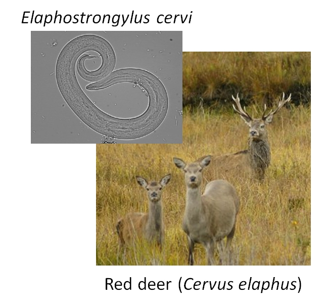

Download the dataset and save it to your R home directory. This is a tab-delimited file (`.txt`), so you need to use `read.table()` instead of `read.csv()`.

```r
dat.name <- "DeerEcervi.txt"
dat <- read.table(dat.name, sep="\t", header=TRUE)
```

The dataset has the following variables:

| Variable | Meaning |
| --- | --- |
| Farm | Farm (i.e., sampling site) |
| Sex | Sex of deer (1 = female, 2 = male) |
| Length | Deer body length (cm) |
| Ecervi | Parasite load in fecal sample |

Because we are interested in parasite occurrence, not abundance, we should use logistic regression. That is, a binomial GLM with a logit link. We will include a random effect associated with `farm`. Before running the analysis, let’s modify the variables in the dataset. First, define a response variable `y` that is 1 when parasites are present and 0 when parasite are absent. Then, center the deer lengths by subtracting the mean length. Finally, recode the sexes as `f` and `m` instead of 1 and 2. This is optional but will make things easier later.

```r
dat$y <- ifelse(dat$Ecervi > 0, 1, 0)
dat$len <- dat$Length-mean(dat$Length)
dat$sex <- ifelse(dat$Sex==1, "f", "m")
```

Now we can fit a model. Like the original authors, we will investigate the effects of sex, size, and farm. The model for parasite presence *y* in individual *j* on farm *i*, with probability $p_{ij}$, varies with length $L_{ij}$, sex $S_{ij}$, the interaction between sex and length $S_{ij}L_{ij}$, and farm $F_i$ as:

$$y_i \sim Bernoulli\left(p_{ij}\right)$$
$$logit\left(p_{ij}\right)=\beta_0+\beta_1L_{ij}+\beta_2S_{ij}+\beta_3L_{ij}S_{ij}+\gamma_i$$
$$\gamma_i \sim Normal\left(\mu_\gamma,\sigma_{\gamma}\right)$$

In this model farm has a random effect on the intercept, $\gamma_i$. The random effects on the intercepts are assumed to come from a normal distribution with mean $\mu_{\gamma}$ and SD $\sigma_{\gamma}$. Some people prefer to write the model a slightly different way, which combines the overall intercept $\beta_0$ with the random effects on the intercept $\gamma_i$ as a single parameter $\beta_{0,i}$:

$$logit\left(p_{ij}\right)=\beta_{0,i}+\beta_1L_{ij}+\beta_2S_{ij}+\beta_3L_{ij}S_{ij}+\gamma_i$$
$$\beta_{0,i} \sim Normal\left(\mu_{\beta_0},\sigma_{\beta_0}\right)$$

In this format, the combined intercept $\beta_{0,i}$, is equivalent to $\left( \beta_0 + \gamma_i \right)$ for each group *i*. This is the way I prefer to write GLMM formulas because it makes it more clear what the random effects are really doing.

GLMM can be fit with `lme4::glmer()`:

```r
library(lme4)
mod1 <- glmer(y~len*sex+(1|Farm), data=dat, family=binomial)
summary(mod1)
```

```
## Generalized linear mixed model fit by maximum likelihood
##   (Laplace Approximation) [glmerMod]
##  Family: binomial  ( logit )
## Formula: y ~ len * sex + (1 | Farm)
##    Data: dat
##
##      AIC      BIC   logLik deviance df.resid
##    832.6    856.1   -411.3    822.6      821
##
## Scaled residuals:
##     Min      1Q  Median      3Q     Max
## -6.2678 -0.6090  0.2809  0.5022  3.4546
##
## Random effects:
##  Groups Name        Variance Std.Dev.
##  Farm   (Intercept) 2.391    1.546
## Number of obs: 826, groups:  Farm, 24
##
## Fixed effects:
##             Estimate Std. Error z value Pr(>|z|)
## (Intercept) 0.938969   0.356004   2.638  0.00835 **
## len         0.038964   0.006917   5.633 1.77e-08 ***
## sexm        0.624487   0.222938   2.801  0.00509 **
## len:sexm    0.035859   0.011409   3.143  0.00167 **
## ---
## Signif. codes:  0 '***' 0.001 '**' 0.01 '*' 0.05 '.' 0.1 ' ' 1
##
## Correlation of Fixed Effects:
##          (Intr) len    sexm
## len      -0.107
## sexm     -0.189  0.238
## len:sexm  0.091 -0.514  0.232
```

The model is essentially an ANCOVA model (continuous predictor that interacts with a factor, `sex`) fit as a binomial GLM (logistic regression) with a random effect of another factor (`Farm`). Interpreting the fixed effects length (`len`) and `sex` is a little tricky because of the interaction. We have to be careful and think about which observations each coefficient applies to:

- The printed intercept, `(Intercept)`, of 0.939 is the intercept for the baseline `sex`, females, regardless of farm effects.
- The printed coefficient for length (`len`), 0.038, is the slope for the baseline `sex` (females).
- The intercept for males is the baseline intercept plus the effect of being male: 0.9389 + 0.6244 = 1.5634.
- The slope for males is the baseline slope plus the effect of being male on the slope: 0.0389 + 0.0358 = 0.0748.

Thus, the fixed effects for females are:

$$logit\left(p_j\right)=0.939+0.038L_j$$

And the fixed effects for males are:

$$logit\left(p_j\right)=\left(0.939+0.624\right)+\left(0.039+0.036\right)L_j=1.563+0.075L_j$$

Now let’s plot the model predictions against the original data. We’ll assemble a new dataset that covers the domain of *x* values (centered lengths), both sexes, and the 24 farms.

```r
farms <- sort(unique(dat$Farm))
nfarm <- length(farms)
agg <- aggregate(len~sex, data=dat, range)
agg <- agg[[2]]
n <- 50
dx1 <- expand.grid(
    sex="f",
    len=seq(agg[1,1], agg[1,2], length=n),
    Farm=farms)
dx2 <- expand.grid(
    sex="m",
    len=seq(agg[2,1], agg[2,2], length=n),
    Farm=farms)
dx <- rbind(dx1, dx2)
```

Now generate the predictions:

```r
pred <- predict(mod1, newdata=data.frame(dx), type="link")
dx$y <- pred

# inverse link function
dx$py <- plogis(dx$y)
```

The predictions we just calculated are specific to each farm. The “average” probability, which ignores farm, can be obtained either predicting without random effects (safest), by manual calculation using the fixed effects (more trouble but generally okay) or by averaging across levels of the random effect (not recommended). The first two methods are demonstrated below, but we’re going to use the outputs from the first.

```r
# method 1: predict with re.form=NA
dx3 <- dx[which(dx$Farm == farms[1]),]
dx3$y <- predict(mod1,
    newdata=data.frame(dx3),
    type="link", re.form=NA)
dx3$py <- plogis(dx3$y)

# method 1 ver. 2: predict to a new level of the random effect
dx5 <- dx[which(dx$Farm == farms[1]),]
dx5$Farm <- NA
dx5$y <- predict(mod1,
    newdata=data.frame(dx5),
    type="link", re.form=NA,
    allow.new.levels=TRUE)
dx5$py <- plogis(dx5$y)

# method 2: manually calculate
dx4 <- dx3
flag <- which(dx4$sex == "f")
dx4$y[flag] <- 0.939+0.038*dx4$len[flag]
dx4$y[-flag] <- 1.563+0.075*dx4$len[-flag]
```

For clarity, we will plot females and males on separate plots. Also for clarity, we will not plot the data and instead will plot the predicted probabilities.

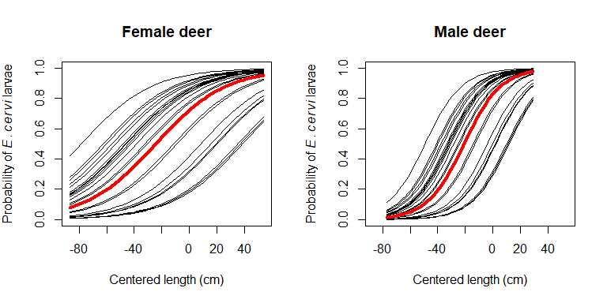

```r
par(mfrow=c(1,2))
plot(dx$len, dx$py, type="n", ylim=c(0,1),
    xlab="Centered length (cm)",
    ylab=expression(Probability~of~italic(E)*.~italic(cervi)~larvae))
use.dx <- dx[which(dx$sex == "f"),]
for(i in 1:nfarm){
    flag <- which(use.dx$Farm == farms[i])
    points(use.dx$len[flag], use.dx$py[flag], type="l")
}
flag <- which(dx3$sex == "f")
points(dx3$len[flag], dx3$py[flag], type="l", lwd=4, col="red")
title(main="Female deer")

plot(dx$len, dx$py, type="n", ylim=c(0,1),
    xlab="Centered length (cm)",
    ylab=expression(Probability~of~italic(E)*.~italic(cervi)~larvae))
use.dx <- dx[which(dx$sex == "m"),]
for(i in 1:nfarm){
    flag <- which(use.dx$Farm == farms[i])
    points(use.dx$len[flag], use.dx$py[flag], type="l")
}
flag <- which(dx3$sex == "m")
points(dx3$len[flag], dx3$py[flag], type="l", lwd=4, col="red")
title(main="Male deer")
```

It is worth asking what the 95% CI of the predicted probability for an “average” farm would be. We can calculate this using some information from the summary of model 1 (see above). The random effects on the intercept for each farm have mean 0 and SD = 1.546. Because this model has only a random intercept, and not a random slope, we can express uncertainty about the predicted value (on the logit scale) by shifting the predicted value up or down. This means that the predicted value (on the logit scale) has a confidence interval defined by a normal distribution with the predicted value as the mean, and a standard deviation of 1.546. For any predicted value $E(logit(p))$, the 95% CI can be approximated as $E(logit(p)) \pm 1.96\times1.546$.

In R we can calculate the CI directly using the normal distribution quantile functions:

```r
dx5 <- dx[which(dx$Farm == farms[1]),]
dx5$Farm <- NA
dx5$y <- predict(mod1,
    newdata=data.frame(dx5),
    type="link", re.form=NA,
    allow.new.levels=TRUE)
dx5$lo <- qnorm(0.025, dx5$y, 1.546)
dx5$up <- qnorm(0.975, dx5$y, 1.546)

# inverse link function
dx5$py <- plogis(dx5$y)
dx5$plo <- plogis(dx5$lo)
dx5$pup <- plogis(dx5$up)
```

Finally, we can make the plot with the approximated 95% CI:

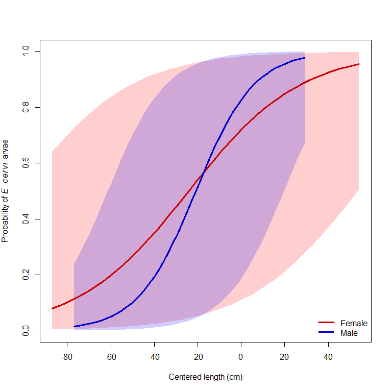

```r
par(mfrow=c(1,1))
plot(dx$len, dx$py, type="n", ylim=c(0,1),
    xlab="Centered length (cm)",
    ylab=expression(Probability~of~italic(E)*.~italic(cervi)~larvae))
flag1 <- which(dx5$sex == "f")
flag2 <- which(dx5$sex == "m")
polygon(x=c(dx5$len[flag1], rev(dx5$len[flag1])),
    y=c(dx5$plo[flag1], rev(dx5$pup[flag1])),
    border=NA, col="#FF000030")
polygon(x=c(dx5$len[flag2], rev(dx5$len[flag2])),
    y=c(dx5$plo[flag2], rev(dx5$pup[flag2])),
    border=NA, col="#0000FF30")
points(dx5$len[flag1], dx5$py[flag1], type="l", lwd=3, col="red3")
points(dx5$len[flag2], dx5$py[flag2], type="l", lwd=3, col="blue3")
legend("bottomright", legend=c("Female", "Male"),
    lwd=3, col=c("red3", "blue3"), bty="n")
```

Because the GLMM we fit was a logistic regression model, you could also calculate an ROC curve and AUC to express the predictive accuracy of the model. For other GLMM, you could perform a cross-validation analysis to see how well the model predicts out-of-sample data.

[**Go back to main page**](https://greenquanteco.github.io/index.html)

# 5 References

Alberti, E., G. Gioia, G. Sironi, S. Zanzani, P. Riccaboni, M. Magrini, and M. Manfredi. 2011. [*Elaphostrongylus cervi* in a population of red deer (*Cervus elaphus*) and evidence of cerebrospinal nematodiasis in small ruminants in the province of Varese, Italy](https://doi.org/10.1017/S0022149X10000647). Journal of Helminthology 85:313–318.

Vicente, J., Y. Fierro, and C. Gortazar. 2005. [Seasonal dynamics of the fecal excretion of *Elaphostrongylus cervi* (Nematoda, Metastrongyloidea) first-stage larvae in Iberian red deer (*Cervus elaphus hispanicus) from southern Spain*](https://doi.org/10.1007/s00436-004-1255-9). Parasitology Research 95:60–64.

# 6 Legal notice

This site is for educational purposes only. This work and its content is released under the [Creative Commons Attribution-ShareAlike 4.0](https://creativecommons.org/licenses/by-sa/4.0/) license. Inclusion of third-party data falls under guidelines of fair use as defined in [section 107 of the US Copyright Act of 1976](https://www.law.cornell.edu/uscode/text/17/107).

[^1]: In principle, there is no reason why you couldn’t have random effects following a non-normal distribution…such a model can be easily defined in BUGS or JAGS but I’m not aware of a way to do it in R.
[^2]: Sometimes model 3 does not converge. If the random number seed is set to 7, only models 1, 2, and 4 will converge. (This was true on my machine. Your results may vary).
[^3]: Nematode image: Alberti et al. (2011). Deer image: O. Deme (https://upload.wikimedia.org/wikipedia/commons/d/df/Red_deer.jpg).